# 01_netcdf_example_adcp

## Working with OOI NetCDF Data

- how to find the data you are looking for
- how to use the machine to machine API to request data
- how to load the NetCDF data into your notebook, once the data request has completed
- how to explore and plot data

The difference between a NetCDF and JSON data request is that NetCDF files are served asynchronously and delivered to a THREDDS server, while the JSON data response is synchronous (instantaneous) and served as a JSON object in the GET response. NetCDF data is undecimated (full data set), while the JSON response is decimated down to a maximum of 20,000 data points.

Login in at https://ooinet.oceanobservatories.org/ and obtain your **API username and API token** under your profile (top right corner).

A great resource for data wrangling and exploration in python can be found at https://chrisalbon.com/. Tip: add "albon" to your search in google when trying to find a common technique and chances are Chris Albon has made a post on how to do it.

```python
# username =''
# token = ''
username = 'OOIAPI-SQI3CFA9Y1D6NO'
token = 'UTM58WKFYG39WC'
```

Optionally, you can handle authentication outside the notebook by setting up a .netrc file in your home directory and loading it with your bash profile. Open your terminal

```
$ touch .netrc
$ chmod 700 .netrc
$ vim .netrc
```

Add the following your your .netrc file:

```
machine ooinet.oceanobservatories.org
login OOIAPI-TEMPD1SPK4K0X
password TEMPCXL48ET2XT
```

Use your username and token. Save the file and uncomment the following cell.

```python
import netrc
netrc = netrc.netrc()
remoteHostName = "ooinet.oceanobservatories.org"
info = netrc.authenticators(remoteHostName)
username = info[0]
token = info[2]
```

[output not shown]

### Part One: Finding and requesting the data.

```python
import requests
import time
```

[figure not shown]

```python
# subsite = 'CE04OSBP'
# node = 'LJ01C'
# sensor = '05-ADCPSI103'
# method = 'streamed'
# stream = 'adcp_velocity_beam'
# beginDT = '2017-08-21T00:00:00.000Z' #begin of first deployement
# # endDT = None
# endDT = '2017-08-22T23:59:59.000Z' #begin of first deployement

# subsite = 'CE06ISSM'
# node = 'MFD35'
# sensor = '04-ADCPTM000'
# method = 'recovered_host'
# stream = 'adcp_velocity_earth'
# beginDT = '2016-11-01T00:00:00.000Z' #begin of first deployement
# endDT = '2016-11-02T00:00:00.000Z'

subsite = 'CE06ISSM'
node = 'MFD37'
sensor = '07-ZPLSCC000'
method = 'telemetered'
stream = 'zplsc_c_instrument'
beginDT = '2016-11-01T00:00:00.000Z' #begin of first deployement
endDT = '2016-11-02T00:00:00.000Z'

# subsite = 'RS03ASHS'
# node = 'MJ03B'
# sensor = '07-TMPSFA301'
# method = 'streamed'
# stream = 'tmpsf_sample'
# beginDT = '2014-09-27T01:01:01.000Z' #begin of first deployement
# endDT = None

# subsite = 'RS03ASHS'
# node = 'MJ03B'
# sensor = '07-TMPSFA301'
# method = 'streamed'
# stream = 'tmpsf_sample'
# beginDT = '2014-09-27T01:01:01.000Z' #begin of first deployement
# endDT = None
```

Send the data request.

```python
base_url = 'https://ooinet.oceanobservatories.org/api/m2m/12576/sensor/inv/'

data_request_url ='/'.join((base_url,subsite,node,sensor,method,stream))
params = {
    'beginDT':beginDT,
    'endDT':endDT,
}
r = requests.get(data_request_url, params=params, auth=(username, token))
data = r.json()
```

The first url in the response is the location on THREDDS where the data is being served. We will get back to using the THREDDS location later.

```python
print(data['allURLs'][0])
```

```
https://opendap.oceanobservatories.org/thredds/catalog/ooi/leewj@uw.edu/20180824T060354-CE06ISSM-MFD37-07-ZPLSCC000-telemetered-zplsc_c_instrument/catalog.html
```

The second url in the response is the regular APACHE server location for the data.

```python
data
```

```
{'allURLs': ['https://opendap.oceanobservatories.org/thredds/catalog/ooi/leewj@uw.edu/20180824T060354-CE06ISSM-MFD37-07-ZPLSCC000-telemetered-zplsc_c_instrument/catalog.html',
  'https://opendap.oceanobservatories.org/async_results/leewj@uw.edu/20180824T060354-CE06ISSM-MFD37-07-ZPLSCC000-telemetered-zplsc_c_instrument'],
 'numberOfSubJobs': 1,
 'outputURL': 'https://opendap.oceanobservatories.org/thredds/catalog/ooi/leewj@uw.edu/20180824T060354-CE06ISSM-MFD37-07-ZPLSCC000-telemetered-zplsc_c_instrument/catalog.html',
 'requestUUID': 'cb94e03e-656d-477e-8794-fb8445ef473c',
 'sizeCalculation': 132607,
 'timeCalculation': 60}
```

We will use this second location to programatically check for a status.txt file to be written, containing the text 'request completed'. This indicates that the request is completed and the system has finished writing out the data to this location. This step may take a few minutes.

```python
%%time
check_complete = data['allURLs'][1] + '/status.txt'
for i in range(1800):
    r = requests.get(check_complete)
    if r.status_code == requests.codes.ok:
        print('request completed')
        break
    else:
        time.sleep(1)
```

```
request completed
CPU times: user 28 ms, sys: 0 ns, total: 28 ms
Wall time: 441 ms
```

## Part Two: Loading the data into the notebook.

```python
import re
import xarray as xr
import pandas as pd
import os
```

Next we will parse the html at the location where the files are being delivered to get the list of the NetCDF files written to THREDDS. Note that seperate NetCDF files are created at 500 mb intervals and when there is a new deployment.

```python
url = data['allURLs'][0]
# url = 'https://opendap.oceanobservatories.org/thredds/catalog/ooi/ooidatateam@gmail.com/20180221T030103-RS03ASHS-MJ03B-07-TMPSFA301-streamed-tmpsf_sample/catalog.html'
tds_url = 'https://opendap.oceanobservatories.org/thredds/dodsC'
datasets = requests.get(url).text
urls = re.findall(r'href=[\'"]?([^\'" >]+)', datasets)
x = re.findall(r'(ooi/.*?.nc)', datasets)
for i in x:
    if i.endswith('.nc') == False:
        x.remove(i)
for i in x:
    try:
        float(i[-4])
    except:
        x.remove(i)
datasets = [os.path.join(tds_url, i) for i in x]
```

```python
datasets
```

```
['https://opendap.oceanobservatories.org/thredds/dodsC/ooi/leewj@uw.edu/20180824T060354-CE06ISSM-MFD37-07-ZPLSCC000-telemetered-zplsc_c_instrument/deployment0005_CE06ISSM-MFD37-07-ZPLSCC000-telemetered-zplsc_c_instrument_20161101T003505.298000-20161101T233504.898000.nc']
```

```python
ds = xr.open_mfdataset(datasets)
ds
```

```
<xarray.Dataset>
Dimensions:                          (channel_1_bins: 18, channel_2_bins: 18, channel_3_bins: 18, channel_4_bins: 18, obs: 24)
Coordinates:
  * obs                              (obs) int32 0 1 2 3 4 5 6 7 8 9 10 11 ...
    time                             (obs) datetime64[ns] dask.array<shape=(24,), chunksize=(24,)>
    lat                              (obs) float64 dask.array<shape=(24,), chunksize=(24,)>
    lon                              (obs) float64 dask.array<shape=(24,), chunksize=(24,)>
Dimensions without coordinates: channel_1_bins, channel_2_bins, channel_3_bins, channel_4_bins
Data variables:
    deployment                       (obs) int32 dask.array<shape=(24,), chunksize=(24,)>
    id                               (obs) |S64 dask.array<shape=(24,), chunksize=(24,)>
    burst_number                     (obs) float64 dask.array<shape=(24,), chunksize=(24,)>
    driver_timestamp                 (obs) datetime64[ns] dask.array<shape=(24,), chunksize=(24,)>
    ingestion_timestamp              (obs) datetime64[ns] dask.array<shape=(24,), chunksize=(24,)>
    internal_timestamp               (obs) datetime64[ns] dask.array<shape=(24,), chunksize=(24,)>
    port_timestamp                   (obs) datetime64[ns] dask.array<shape=(24,), chunksize=(24,)>
    preferred_timestamp              (obs) object dask.array<shape=(24,), chunksize=(24,)>
    provenance                       (obs) |S64 dask.array<shape=(24,), chunksize=(24,)>
    serial_number                    (obs) object dask.array<shape=(24,), chunksize=(24,)>
    zplsc_c_battery_voltage          (obs) float64 dask.array<shape=(24,), chunksize=(24,)>
    zplsc_c_frequency_channel_1      (obs) float64 dask.array<shape=(24,), chunksize=(24,)>
    zplsc_c_frequency_channel_2      (obs) float64 dask.array<shape=(24,), chunksize=(24,)>
    zplsc_c_frequency_channel_3      (obs) float64 dask.array<shape=(24,), chunksize=(24,)>
    zplsc_c_frequency_channel_4      (obs) float64 dask.array<shape=(24,), chunksize=(24,)>
    zplsc_c_phase                    (obs) float64 dask.array<shape=(24,), chunksize=(24,)>
    zplsc_c_pressure                 (obs) float64 dask.array<shape=(24,), chunksize=(24,)>
    zplsc_c_temperature              (obs) float64 dask.array<shape=(24,), chunksize=(24,)>
    zplsc_c_tilt_x                   (obs) float64 dask.array<shape=(24,), chunksize=(24,)>
    zplsc_c_tilt_y                   (obs) float64 dask.array<shape=(24,), chunksize=(24,)>
    zplsc_c_transmission_timestamp   (obs) float64 dask.array<shape=(24,), chunksize=(24,)>
    zplsc_c_values_channel_1         (obs, channel_1_bins) float64 dask.array<shape=(24, 18), chunksize=(24, 18)>
    zplsc_c_values_channel_2         (obs, channel_2_bins) float64 dask.array<shape=(24, 18), chunksize=(24, 18)>
    zplsc_c_values_channel_3         (obs, channel_3_bins) float64 dask.array<shape=(24, 18), chunksize=(24, 18)>
    zplsc_c_values_channel_4         (obs, channel_4_bins) float64 dask.array<shape=(24, 18), chunksize=(24, 18)>
    zplsc_c_temperature_qc_executed  (obs) float64 dask.array<shape=(24,), chunksize=(24,)>
    zplsc_c_temperature_qc_results   (obs) float64 dask.array<shape=(24,), chunksize=(24,)>
    zplsc_c_pressure_qc_executed     (obs) float64 dask.array<shape=(24,), chunksize=(24,)>
    zplsc_c_pressure_qc_results      (obs) float64 dask.array<shape=(24,), chunksize=(24,)>
Attributes:
    _NCProperties:                      version=1|netcdflibversion=4.4.1.1|hd...
```

[output cut: 56 more lines]

```
    time_coverage_resolution:           P3449.98S
    geospatial_lat_min:                 47.13359
    geospatial_lat_max:                 47.13359
    geospatial_lat_units:               degrees_north
    geospatial_lat_resolution:          0.1
    geospatial_lon_min:                 -124.27158
    geospatial_lon_max:                 -124.27158
    geospatial_lon_units:               degrees_east
    geospatial_lon_resolution:          0.1
    geospatial_vertical_units:          meters
    geospatial_vertical_resolution:     0.1
    geospatial_vertical_positive:       down
    DODS.strlen:                        5
    DODS.dimName:                       string5
    DODS_EXTRA.Unlimited_Dimension:     obs
```

```python
%matplotlib inline
```

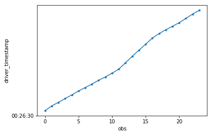

```python
ds['driver_timestamp'].plot(marker='.')
```

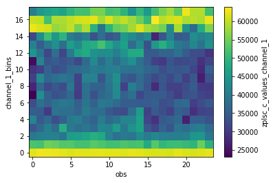

```python
ds['zplsc_c_values_channel_1'].T.plot()
```

```python
ds['zplsc_c_values_channel_1'].lat
```

```
<xarray.DataArray 'lat' (obs: 24)>
dask.array<shape=(24,), dtype=float64, chunksize=(24,)>
Coordinates:
  * obs      (obs) int32 0 1 2 3 4 5 6 7 8 9 10 11 12 13 14 15 16 17 18 19 ...
    time     (obs) datetime64[ns] dask.array<shape=(24,), chunksize=(24,)>
    lat      (obs) float64 dask.array<shape=(24,), chunksize=(24,)>
    lon      (obs) float64 dask.array<shape=(24,), chunksize=(24,)>
Attributes:
    units:          degrees_north
    standard_name:  latitude
    axis:           Y
    _ChunkSizes:    24
```

Use xarray to open all netcdf files as a single xarray datase, swap the dimention from obs to time and and examine the content.

```python
ds = xr.open_mfdataset(datasets)
ds = ds.swap_dims({'obs': 'time'})
ds = ds.chunk({'time': 100})
ds
```

[output not shown]

[output cut: 73 more lines]

[output not shown]

## Part Three: Exploring the data.

```python
import datetime
import matplotlib.pyplot as plt
import matplotlib.dates as dates
import numpy as np
```

Use built in xarray plotting functions to inspect beam intensity data.

```python
ds_copy = ds.copy()
```

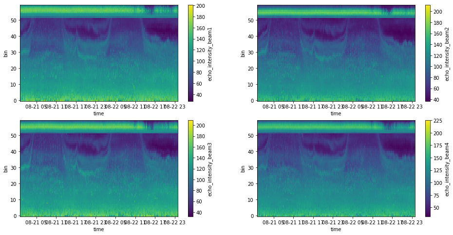

```python
fig,ax = plt.subplots(2,2,figsize=(16,8))
ds['echo_intensity_beam1'].T.plot(ax=ax[0,0])
ds['echo_intensity_beam2'].T.plot(ax=ax[0,1])
ds['echo_intensity_beam3'].T.plot(ax=ax[1,0])
ds['echo_intensity_beam4'].T.plot(ax=ax[1,1])
plt.show()
```

```python
%%time
from dask.diagnostics import ProgressBar
with ProgressBar():
    df = ds['temperature12'].to_dataframe()
    df = df.resample('min').mean()
```

```
CPU times: user 2min 13s, sys: 1min 32s, total: 3min 46s
Wall time: 13min 39s
```

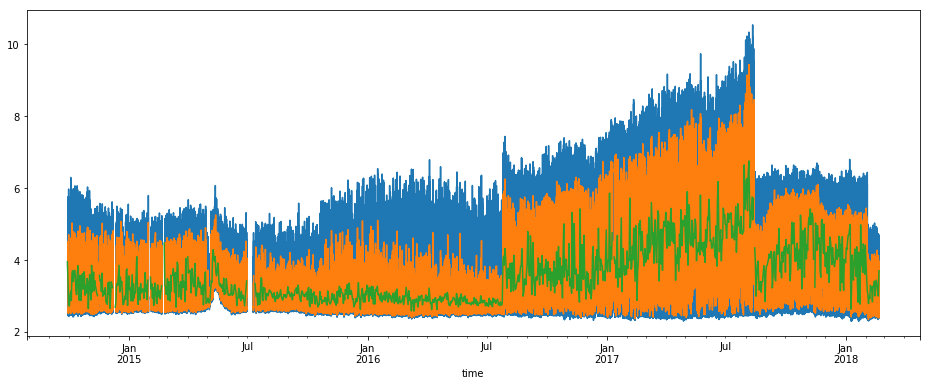

```
CPU times: user 9.21 s, sys: 682 ms, total: 9.9 s
Wall time: 9.24 s
```

```python
%%time
plt.close()
fig, ax = plt.subplots()
fig.set_size_inches(16, 6)
df['temperature12'].plot(ax=ax)
df['temperature12'].resample('H').mean().plot(ax=ax)
df['temperature12'].resample('D').mean().plot(ax=ax)
plt.show()
```

Now we are getting a better sense of the data. Let's convert time to ordinal, grab temperature values and re-examine using hexagonal bi-variate binning. Again, this step may take a few minutes, but should run faster during the workshop. If the step fails entirely for any reason, please send us a note on slack.

```python
%%time
time = []
time_pd = pd.to_datetime(ds.time.values.tolist())
for i in time_pd:
    i = np.datetime64(i).astype(datetime.datetime)
    time.append(dates.date2num(i))
```

```
CPU times: user 2min 9s, sys: 6.96 s, total: 2min 16s
Wall time: 2min 12s
```

```python
temperature = ds['temperature12'].values.tolist()
```

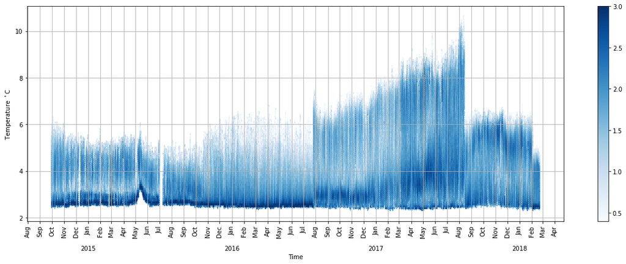

```python
plt.close()
fig, ax = plt.subplots()
fig.set_size_inches(16, 6)

hb1 = ax.hexbin(time, temperature, bins='log', vmin=0.4, vmax=3, gridsize=(1100, 100), mincnt=1, cmap='Blues')
fig.colorbar(hb1)
ax.yaxis.grid(True)
ax.xaxis.grid(True)
# ax.set_xlim(datetime.datetime(2015, 12, 1, 0, 0),datetime.datetime(2016, 7, 25, 0, 0))
# ax.set_ylim(2,11)
years = dates.YearLocator()
months = dates.MonthLocator()
yearsFmt = dates.DateFormatter('\n\n\n%Y')
monthsFmt = dates.DateFormatter('%b')
ax.xaxis.set_major_locator(months)
ax.xaxis.set_major_formatter(monthsFmt)
ax.xaxis.set_minor_locator(years)
ax.xaxis.set_minor_formatter(yearsFmt)
plt.tight_layout()
plt.setp(ax.xaxis.get_majorticklabels(), rotation=90)
plt.ylabel('Temperature $^\circ$C')
plt.xlabel('Time')
plt.show()
```